# Markets and Their Invisible Foundations

HEKA22—Lecture 6

Jonas Kreutzer

2026-05-21

# Learning Objectives

**By the end of today’s lecture you should be able to:**

1. Explain Polanyi’s distinction between real and fictitious commodities and what it implies for the limits of self-regulating markets
2. Describe the double movement and identify contemporary examples
3. Articulate the ecofeminist critique that mainstream economics renders unpaid care work and ecosystem functions invisible
4. Apply an intersectional lens to a provisioning system (e.g., healthcare) and identify whose labor sustains it

# Part I: Markets and Embeddedness

## What is a market?

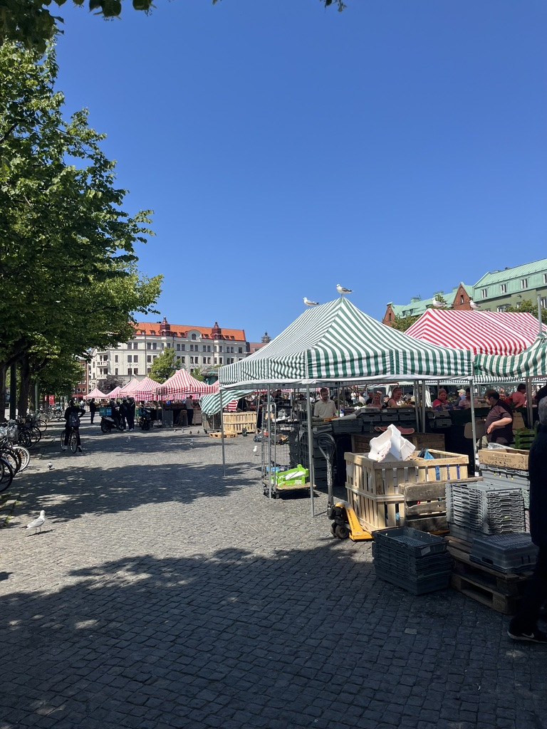

## Commodities

> a substance or product that can be traded, bought, or sold

[Cambridge Dictionary](https://dictionary.cambridge.org/us/dictionary/english/commodity)

## The double movement

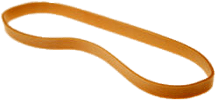

Disembedding of markets followed by societal self-protection

## The Rise of Market Economies in Italy in the Middle Ages (1000~1300) (van Bavel 2016)

[figure not shown]

Effects of Good Government in the City – Ambrogio Lorenzetti (1338)

## Happily ever after?

“Instead of leading to ever more open exchange and equal opportunities, markets in the longer run had adverse effects. As will be shown in this section, both the context in which these markets functioned and their organization started to change and became more unbalanced and skewed towards the interests of the elite, especially in the fourteenth century.” (van Bavel 2016, 15)

## The Decline of Market Economies in Italy in the Middle Ages (~1300-1500) (van Bavel 2016)

[figure not shown]

Effects of Bad Government in the City – Ambrogio Lorenzetti (1338)

# Part II: Ecofeminist Perspectives

## Employment is a subset of work

## The Motherhood Penalty in Sweden

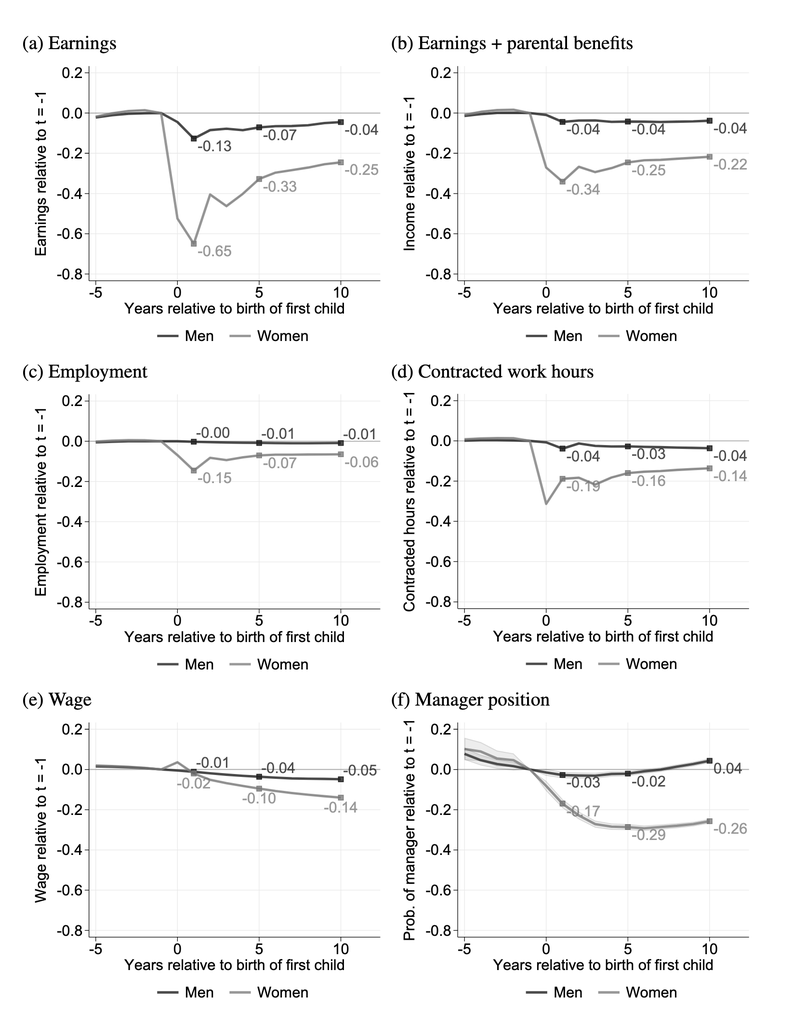

Figure 1: Impact of children on labor market outcomes copied from Sundberg (2024, 11)

## The Marketization of Motherhood and Care

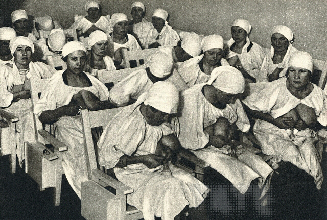

Figure 2: Wet Nurses in USSR

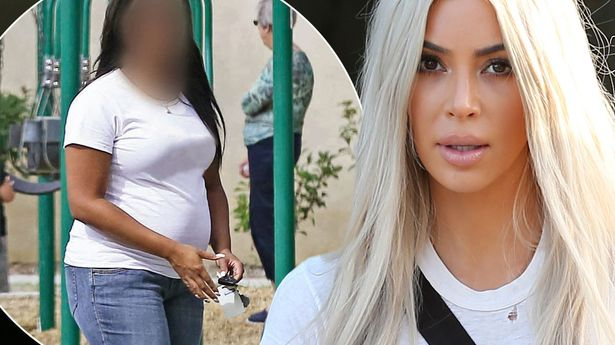

Figure 3: La’Reina Haynes, Kim Kardashian’s Surrogate

## Power struggle over monetized labor

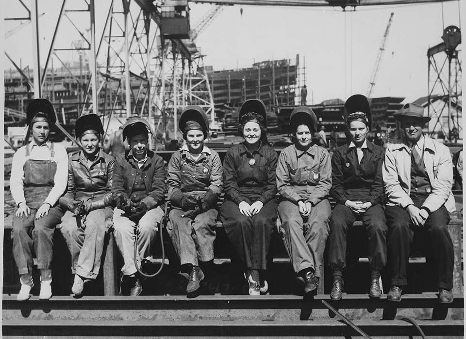

Figure 4: By the end of World War II, more than 19 million women were in the workforce and 350,000 women had served in the US Armed Forces.

[figure not shown]

Figure 5: 1955 Good House Wife’s Guide

### Bargaining Positions

[video not shown]

[Institute for New Economic Thinking’s “Feminist Economics”](https://www.ineteconomics.org/perspectives/videos/feminist-economics)

## Zooming in on Intersectionality in Sweden

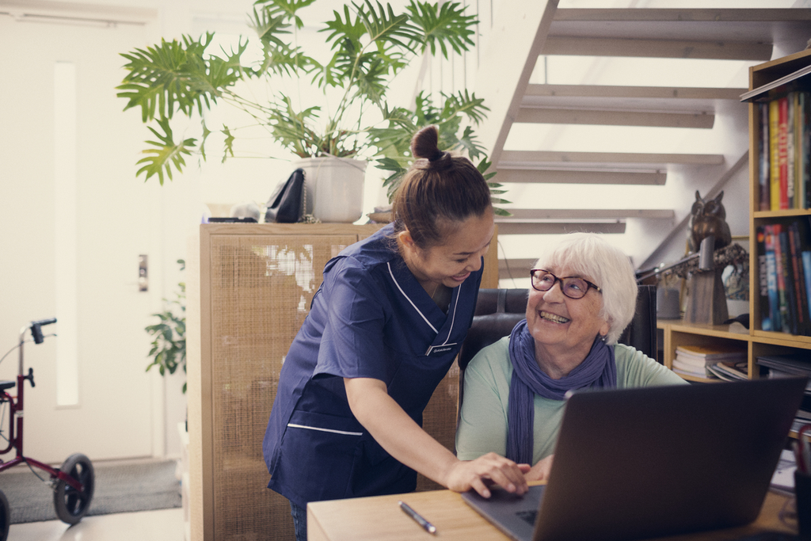

Hemtjänst and Care Work

## Rot- och Rutavdrag

När du anlitar ett företag för reparation, underhåll, ombyggnad eller tillbyggnad kan du få rotavdrag för delar av arbetskostnaden. Du kan också få rutavdrag för hushållsnära tjänster som städning och trädgårdsarbete. Material och andra kostnader, som resekostnader, ger däremot inte rätt till avdrag.

> … strategies that strengthen non-monetized social-ecological provisioning without monetizing it, thereby questioning the arbitrariness of what is (un-/under-)paid in capitalist economies. Dengler and Plank (2024, 1)

### Time Politics

### Decouple livelihoods from employment: UBI and UBS

**U**niversal **B**asic **I**ncome

**U**niversal **B**asic **S**ervices

# Checking in on Learning Objectives

**By the end of today’s lecture you should be able to:**

1. Explain Polanyi’s distinction between real and fictitious commodities and what it implies for the limits of self-regulating markets
2. Describe the double movement and identify contemporary examples
3. Articulate the ecofeminist critique that mainstream economics renders unpaid care work and ecosystem functions invisible
4. Apply an intersectional lens to a provisioning system (e.g., healthcare) and identify whose labor sustains it

## References

Dengler, Corinna, and Christina Plank. 2024. “Foregrounding Invisible Foundations: (Eco-)feminist Perspectives on Provisioning Systems.” *Sustainability: Science, Practice and Policy* 20 (1): 2312667. https://doi.org/10.1080/15487733.2024.2312667.

Sundberg, Anton. 2024. *The Child Penalty in Sweden: Evidence, Trends, and Child Gender*. 2024:12. IFAU - Institute for Evaluation of Labour Market and Education Policy.

van Bavel, Bas. 2016. “Markets in Medieval City-States: The Centre and North of Italy, 1000–1500.” In *The Invisible Hand?* Oxford University Press. https://doi.org/10.1093/acprof:oso/9780199608133.003.0003.